# Practice 6

Guglielmo Bonifazi, Emanuele Sorgente

01/11/2021

```r
library(MASS)
library(klaR)
library(ggplot2)
```

```r
data=iris
str(iris)
```

```
## 'data.frame':    150 obs. of  5 variables:
##  $ Sepal.Length: num  5.1 4.9 4.7 4.6 5 5.4 4.6 5 4.4 4.9 ...
##  $ Sepal.Width : num  3.5 3 3.2 3.1 3.6 3.9 3.4 3.4 2.9 3.1 ...
##  $ Petal.Length: num  1.4 1.4 1.3 1.5 1.4 1.7 1.4 1.5 1.4 1.5 ...
##  $ Petal.Width : num  0.2 0.2 0.2 0.2 0.2 0.4 0.3 0.2 0.2 0.1 ...
##  $ Species     : Factor w/ 3 levels "setosa","versicolor",..: 1 1 1 1 1 1 1 1 1 1 ...
```

```r
lda_fit=lda(Species ~ Sepal.Length + Petal.Width, data = data)
qda_fit=qda(Species ~ Sepal.Length + Petal.Width, data = data)
NaiveBayes_fit=NaiveBayes(Species ~ Sepal.Length + Petal.Width, data = data)
```

LDA:

```r
setosa=iris[which(iris['Species']=='setosa'),]
virginica=iris[which(iris['Species']=='virginica'),]
versicolor=iris[which(iris['Species']=='versicolor'),]


n=150
k=3
n1=n2=n3=50

cov_setosa=cov(setosa[,c(1,4)])
cov_virginica=cov(virginica[,c(1,4)])
cov_versicolor=cov(versicolor[,c(1,4)])
```

The unique covariance Matrix:

```r
Sigma= 1/(n - k) * (cov_setosa * (n1 - 1) + cov_virginica * (n2 - 1) + cov_versicolor*(n3-1))
```

The means:

```r
mu_set_lda=c(mean(setosa$Sepal.Length),mean(setosa$Petal.Width))
mu_vir_lda=c(mean(virginica$Sepal.Length),mean(virginica$Petal.Width))
mu_ver_lda=c(mean(versicolor$Sepal.Length),mean(versicolor$Petal.Width))
```

QDA: Dropping down the assumption of same covariance matrix for for each class distribution of the predictors we have simply:

```r
Sigma_set_qda=cov_setosa
mu_set_qda=c(mean(setosa$Sepal.Length),mean(setosa$Petal.Width))
Sigma_set_qda
```

```
##              Sepal.Length Petal.Width
## Sepal.Length   0.12424898  0.01033061
## Petal.Width    0.01033061  0.01110612
```

```r
mu_set_qda
```

```
## [1] 5.006 0.246
```

```r
Sigma_vir_qda=cov_virginica
mu_vir_qda=c(mean(virginica$Sepal.Length),mean(virginica$Petal.Width))
Sigma_vir_qda
```

```
##              Sepal.Length Petal.Width
## Sepal.Length   0.40434286  0.04909388
## Petal.Width    0.04909388  0.07543265
```

```r
mu_vir_qda
```

```
## [1] 6.588 2.026
```

```r
Sigma_ver_qda=cov_versicolor
mu_ver_qda=c(mean(versicolor$Sepal.Length),mean(versicolor$Petal.Width))
Sigma_ver_qda
```

```
##              Sepal.Length Petal.Width
## Sepal.Length   0.26643265  0.05577959
## Petal.Width    0.05577959  0.03910612
```

```r
mu_ver_qda
```

```
## [1] 5.936 1.326
```

Naive Bayes: Given that all the predictors are indipendent in Naive Bayes assumptions and that we are using the assumption of Gaussian distribution for each predictors, we have k sigmas diagonal matrixes.

```r
sigma_set_nb=diag(c(var(setosa$Sepal.Length),var(setosa$Petal.Width)))
sigma_set_nb
```

```
##          [,1]       [,2]
## [1,] 0.124249 0.00000000
## [2,] 0.000000 0.01110612
```

```r
sigma_vir_nb=diag(c(var(virginica$Sepal.Length),var(virginica$Petal.Width)))
sigma_vir_nb
```

```
##           [,1]       [,2]
## [1,] 0.4043429 0.00000000
## [2,] 0.0000000 0.07543265
```

```r
sigma_ver_nb=diag(c(var(versicolor$Sepal.Length),var(versicolor$Petal.Width)))
sigma_ver_nb
```

```
##           [,1]       [,2]
## [1,] 0.2664327 0.00000000
## [2,] 0.0000000 0.03910612
```

The means are the same found for the previous models:

```r
mu_set_nb=c(mean(setosa$Sepal.Length),mean(setosa$Petal.Width))
mu_vir_nb=c(mean(virginica$Sepal.Length),mean(virginica$Petal.Width))
mu_ver_nb=c(mean(versicolor$Sepal.Length),mean(versicolor$Petal.Width))
```

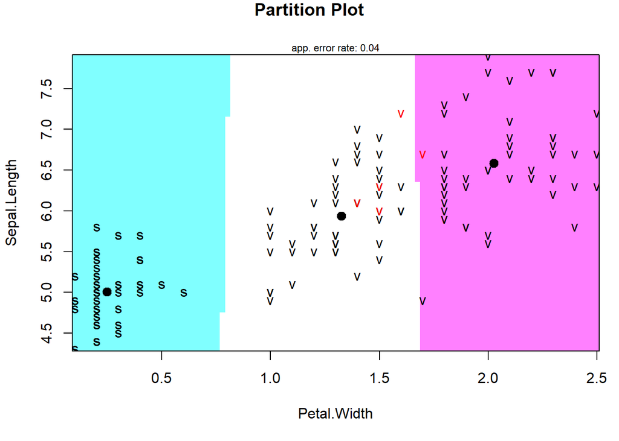

```r
library(patchwork)
x11()
partimat(Species ~ Sepal.Length + Petal.Width, data = data,method='lda')
```

As we can see, the boundaries are given by linear functions

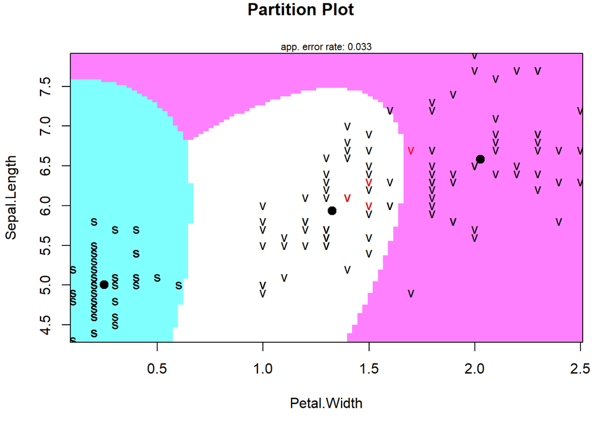

```r
partimat(Species ~ Sepal.Length + Petal.Width, data = data,method='qda')
```

As we can see, the boundaries are given by quadratic functions

```r
partimat(Species ~ Sepal.Length + Petal.Width, data = data,method='naiveBayes')
```

```
## Caricamento dei namespace richiesti: e1071
```

[figure not shown]

Even for Naive Bayes the discriminant takes to quadratic boundaries.

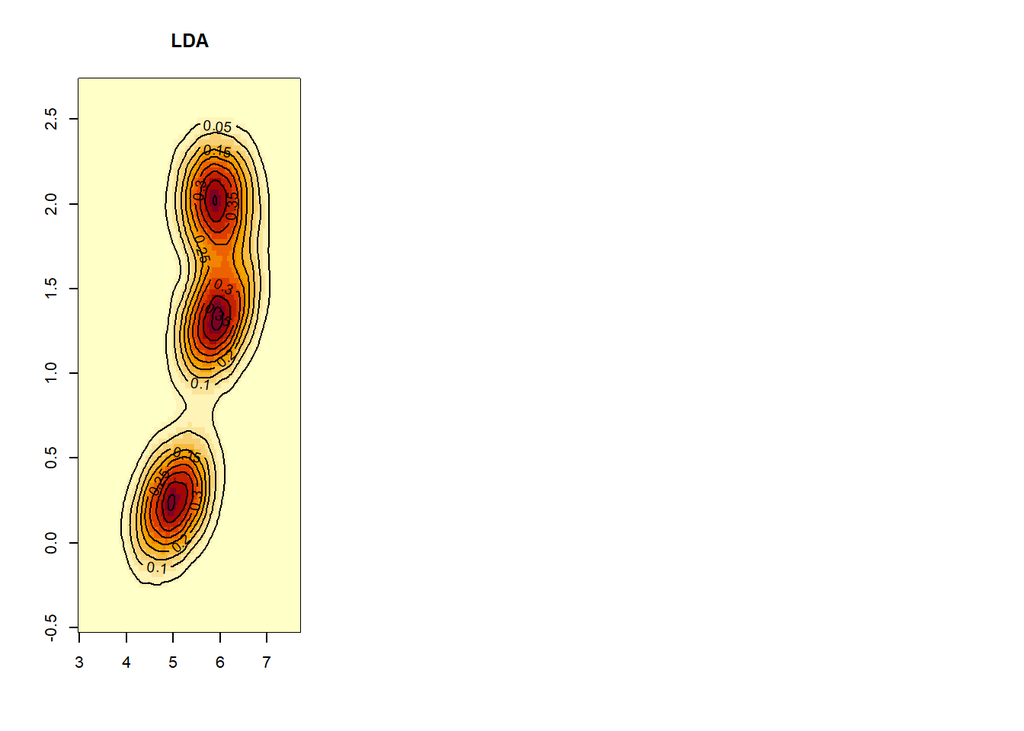

```r
x11()
par(mfrow=c(1,3))
bivn = mvrnorm(10000, mu = mu_set_lda,
                Sigma )
bivn1= mvrnorm(10000, mu = mu_ver_lda,
                Sigma )
bivn2= mvrnorm(10000, mu = mu_vir_lda,
                Sigma )
bivn.mix = kde2d(c(bivn[,1],bivn1[,1],bivn1[,1]),
                  c(bivn[,2],bivn1[,2],bivn2[,2]), n = 100)
image(bivn.mix,main='LDA')
contour(bivn.mix, add = T)
```

QDA:

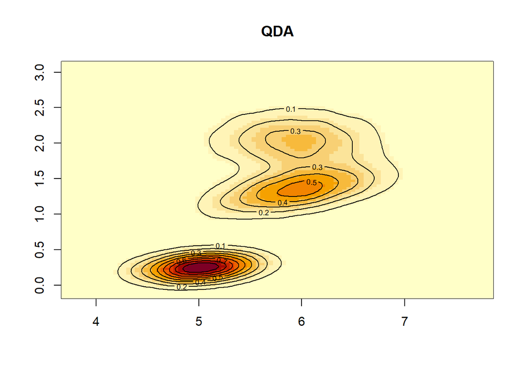

```r
bivn = mvrnorm(10000, mu = mu_set_lda,
               Sigma_set_qda )
bivn1= mvrnorm(10000, mu = mu_ver_lda,
               Sigma_ver_qda )
bivn2= mvrnorm(10000, mu = mu_vir_lda,
               Sigma_vir_qda )
bivn.mix = kde2d(c(bivn[,1],bivn1[,1],bivn1[,1]),
                 c(bivn[,2],bivn1[,2],bivn2[,2]), n = 100)
image(bivn.mix,main='QDA')
contour(bivn.mix, add = T)
```

NAIVE BAYES:

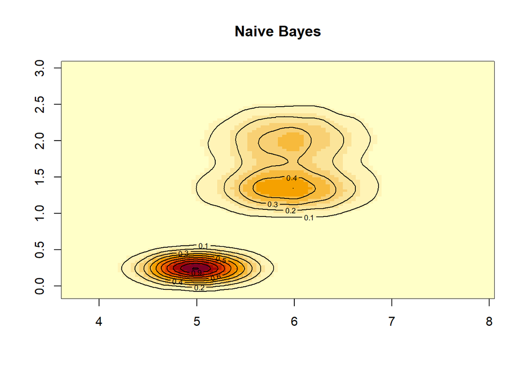

```r
bivn = mvrnorm(10000, mu = mu_set_lda,
               sigma_set_nb )
bivn1= mvrnorm(10000, mu = mu_ver_lda,
               sigma_ver_nb )
bivn2= mvrnorm(10000, mu = mu_vir_lda,
               sigma_vir_nb )
bivn.mix = kde2d(c(bivn[,1],bivn1[,1],bivn1[,1]),
                 c(bivn[,2],bivn1[,2],bivn2[,2]), n = 100)
image(bivn.mix,main='Naive Bayes')
contour(bivn.mix, add = T)
```